# Tema 03 - Visualización de Datos

Universidad de Alicante, Curso 2021/22

## Introducción

- La visualización es una forma de **obtener información** que no se vería en los datos en bruto (en una hoja de cálculo)
  - posición central, dispersión, valores extremos
  - identificar patrones
- En un buen gráfico, la audiencia encuentra *obvias* las ideas a transmitir
  - NO abrumar con muchos hallazgos interesantes
- Usaremos la biblioteca `ggplot2` (de `tidyverse`), basada en la teoría de visualización conocida como *Gramática de Gráficos* (Wilkinson, 2005)
  - algunos gráficos simples requieren más opciones que en R base
  - PERO ofrece facilidades para gráficos complejos y profesionales
- Otras bibliotecas: `rgl` (gráfics 3D), `ggvis` (interactivos)

## Elementos básicos de un gráfico de datos

1. **Señales visuales**: posición, longitud, área, etc.
2. **Sistema de coordenadas**: ¿cómo se organizan los puntos de datos?
   - cartesiano, polar, geográfico
3. **Escala**: ¿cómo se traduce la distancia en algo con significado?
   - numérica lineal, numérica logarítmica, categórica, de tiempo
4. **Contexto**: ¿en relación con qué?
   - títulos, leyendas, etiquetas de ejes, puntos/líneas de referencia
5. Otros: facetas/pequeños múltiplos, capas, animaciones, etc.
- **“Por encima de todo, mostrar los datos”**

## Señales visuales

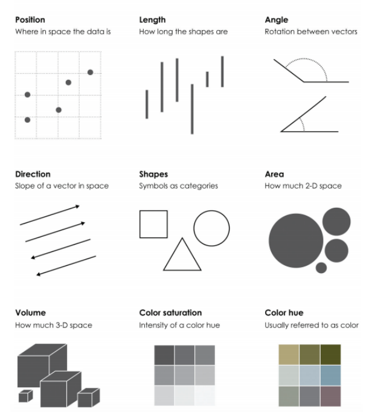

## Sistema de coordenadas

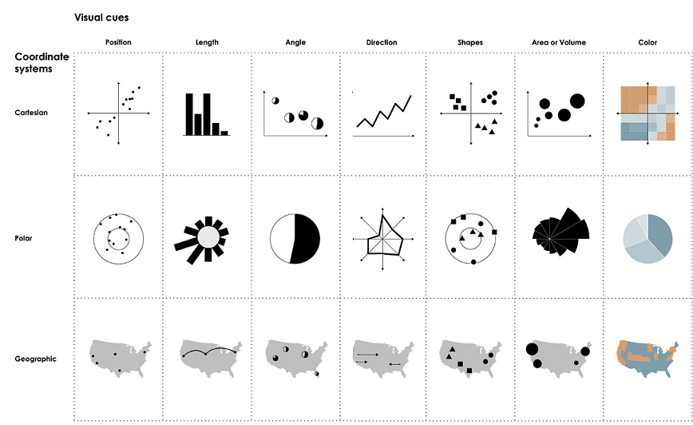

## ¿Qué señales visuales son más efectivas?

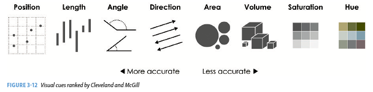

## Escala

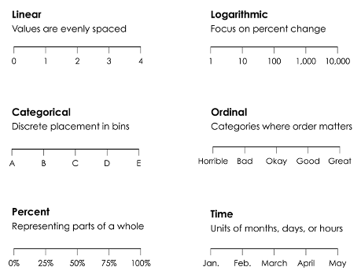

## La “Gramática de Gráficos”

- Especificar bloques *independientes* y combinarlos para crear cualquier visualización gráfica, como las frases a partir de nombres, verbos, objetos, etc.
- Bloques de construcción de un gráfico
  - Datos: `data`
  - Objeto geométrico (qué dibujamos: líneas, puntos, barras, etc.): `geom_*()`
  - Atributos estéticos (del objeto geométrico, como posición, color, forma, tamaño) que transmiten información de una variable: `aes()`
  - Escalas (rango of valores, colores, etc.): `scale_*()`
  - Sistema de Coordenadas
  - Facetas (pequeños múltiplos): `facet_wrap()`, `facet_grid()`

## Creando un “ggplot”

```r
ggplot(data = mpg, aes(x = displ, y = hwy)) +
  geom_point()
```

```r
ggplot(data = mpg) +
  geom_point(mapping = aes(x = displ, y = hwy))
```

- `ggplot(data = mpg)` = gráfico vacío (coordenadas cartesianas, por defecto)
- Añadir capas con `+`: ej., objeto geométrico del tipo puntos = `geom_point()`
- El argumento `mapping`, asociado a `aes()`, define **cómo las variables son asignadas a propiedades visuales**
  - `x` e `y` especifican qué variables asignar a cada eje
- NOTA: el primer código define datos y estética para *todas* las capas que siguen; el segundo solo para el objeto geométrico de puntos.

## Objetos geométricos

- Cada `geom_*()` agrega un tipo diferente de capa/marcas en el gráfico
  - puntos (`geom_point`, para diagramas de dispersión, de puntos, etc.)
  - líneas (`geom_line`, para series de tiempo, líneas de tendencia, etc.)
  - diagrama de caja (`geom_boxplot`)
  - etc.
- Para una lista de objetos geométricos disponibles, buscar las funciones que comienzan con `geom_` en la Ayuda

## Elementos Estéticos con `aes()`

- Elementos estéticos son “algo que se puede ver” (información)
- Cada elemento estético con `aes()` es un asociación (“mapping”) entre una señal visual y una **variable**
  - posición (p.e., en los ejes x e y)
  - color (color “exterior”)
  - relleno (color “interior”), `fill`
  - forma (de los puntos), `shape`
  - tipo de línea,
  - tamaño, `size`
- Cada `geom` acepta solo un subconjunto de todos los elementos estéticos.
  - En la ayuda de cada `geom` se puede ver qué asignaciones acepta en `aes()`.

## Gráficos como objetos de R

```r
housing   <- read_csv("data/landdata-states.csv")
hp2001Q1  <- housing[housing$Date == 2001.00,]
graf_base <- ggplot(hp2001Q1, aes(y = Structure.Cost, x = Land.Value)) +
                geom_point()                                            # str(graf_base)
```

- Se pueden agregar capas a este objeto gráfico y mostrarlo

```r
graf_base + geom_line()                          # ¿tiene sentido este gráfico?
graf_base + geom_point(aes(color = Home.Value))
```

- Añadimos (una señal visual de) color, NO para “embellecer” sino para representar la información de una variable adicional
- NO saturar el gráfico con estéticas fijas o información innecesaria

```r
graf_base + geom_point(aes(size = Home.Price.Index,
                 color=Home.Value))                  # ¿qué aportan estas dos variables?
```

## Asociación estética y Asignación de opción fija

- Una asociación (“mapping”) estética, con `aes()`, visualiza una variable
- Una opción estética establece, fuera de `aes()`, un valor fijo de la señal visual

```r
ggplot(hp2001Q1, aes(y = Structure.Cost, x = Land.Value)) +
  geom_point(shape = "cross",  color="red")
```

```r
ggplot(hp2001Q1, aes(y = Structure.Cost, x = Land.Value)) +
  geom_point(aes(shape = region, color=Home.Value))

ggplot(hp2001Q1, aes(y = Structure.Cost, x = Land.Value)) +
  geom_point(aes(shape = region, color=Home.Value),
             size = 3)
```

- Nota: `region`, carácter convertido a factor, se representa en escala categórica

## `esquisse`: una interfaz gráfica para `ggplot2`

- `esquisser()` permite crear un gráfico desde cero: eligiendo el conjunto de datos (en el entorno de trabajo o desde archivo)

```r
#install.packages("esquisse)
library("esquisse")
esquisser()

esquisser(housing, viewer = "browser")
```

- Se pueden elegir muchos (no todos) aspectos del gráfico que veremos en este tema: tipo de gráfico, asignaciones estéticas, títulos, apariencia, etc.
  - también puede trabajar con un subconjunto de datos (emplea una forma que veremos en un tema posterior)
- Genera el código de R que crea el gráfico
- También se puede descargar el gráfico creado

## “Smoothers”

- No todos los `geom`s son formas simples: aquí, por defecto, una línea (función no lineal estimada) y un área (intervalo de confianza de la predicción)

```r
graf_base + geom_smooth()
graf_base + geom_smooth(method = lm, se = FALSE)  # cambiando las opciones
```

- Podríamos agregar la línea de regresión “manualmente”

```r
res <- lm(Structure.Cost ~ Land.Value, data = hp2001Q1)
hp2001Q1$pred.SC <- res[["fitted.values"]]
graf_base +  geom_line(aes(y = pred.SC))  # ERROR: pred.SC no estaba en graf_base

graf_base <- ggplot(hp2001Q1, aes(y = Structure.Cost, x = Land.Value)) + geom_point()
graf_base + geom_line(aes(y = pred.SC))
```

- NO necesitamos repetir la estetica de posición `x` para `geom_line()` porque ya está definida en `graf_base`

## Texto (puntos “etiqueta”)

- Cada `geom` acepta un conjunto particular de asignaciones: `geom_text()` acepta etiquetas (“labels”).

```r
graf_base +
  geom_text(aes(label=State), size = 3)
```

- Si queremos el punto **y** la etiqueta de texto

```r
#install.packages("ggrepel")
library("ggrepel")
graf_base +
  geom_text_repel(aes(label=State), size = 3)
```

## Comentario

- Cada objeto geométrico puede tener características propias
  - usar datos distintos para diferentes objetos,
  - utilizar diferentes estéticas en distintos objetos, etc..
- Usamos solo un subconjunto de los datos para el objeto geométrico de texto

```r
graf_base + geom_point() +
  geom_text_repel(
    data=hp2001Q1[hp2001Q1$State %in% c("NY","NJ","KY"),],
    mapping=aes(label=State), size = 3)
```

```r
graf_base + geom_point() +
  geom_text_repel(
    data=hp2001Q1[hp2001Q1$State=="NY" | hp2001Q1$State=="NJ"| hp2001Q1$State=="KY",],
    mapping=aes(label=State), size = 3))
```

## Transformaciones Estadísticas

- En un diagrama de dispersión, cada punto se grafica en coordenadas x e y iguales al valor original.
  - pero podemos aplicar transformaciones a las variables al ser asociadas

```r
  ggplot(hp2001Q1, aes(x = log(Land.Value), y = Structure.Cost)) + geom_point()
```

- Otros gráficos, como diagramas de cajas, histogramas, líneas de predicción, etc., no representan las variables originales, sino una transformación:
  - para “smoother”, obtener coeficientes y predecir.
  - para diagrama de caja, calcular estadísticos descriptivos

```r
ggplot(hp2001Q1, aes(y = Home.Value/1000)) +  geom_boxplot()
```

- La estadística predeterminada de cada `geom` puede cambiarse

## Modificar las Transformaciones Estadísticas

- Cambiamos el número de grupos (“bins”) con el argumento `binwidth`

```r
graf <- ggplot(housing, aes(x = Home.Value))
graf + geom_histogram(stat = "bin", binwidth=4000)

graf + geom_histogram(stat = "density")             # aproximación continua
graf + geom_density()
graf + geom_histogram(aes(y=..density..), stat = "bin", binwidth=4000) + geom_density()
```

- La estadística predeterminada para `geom_bar` es `stat_count` (contar) , pero puede no ser lo deseado con datos ya transformados: usar OTRA estadística

```r
Region <- table(housing$region)
Region_df <- tibble(nombre = names(Region), casos = Region)

ggplot(Region_df, aes(x=nombre, y=casos)) + geom_bar()
ggplot(Region_df, aes(x=nombre, y=casos)) + geom_bar(stat="identity")  # NO transformar
```

## Escalas: control de la asociación estética

- `aes()` establece la variable asignada, no **cómo** se representa
  - `aes(shape = region)`: qué forma para cada región
  - `aes(color = Home.Value)`: qué color para cada valor
- Las funciones para modificar la escala siguen el esquema `scale_<estética>_<tipo>`
- Argumentos habituales para la escala:
  - `name`: título de la escala (en eje o leyenda)
  - `limits`: el mínimo y el máximo de la escala
  - `breaks`: valores donde deberían aparecer las etiquetas
  - `labels`: las etiquetas que aparecen en cada `break`
- Funciones específicas de escala pueden tener argumentos adicionales

## Ejemplos de modificación de escala

```r
g2 <- ggplot(housing, aes(y = State, x = Home.Price.Index)) + geom_point(aes(color = Date))
```

- Cambiamos las etiquetas para el eje vertical

```r
g2 <- g2 + scale_y_discrete(name="Abrev. Estado")
```

- Modificamos `breaks`, etiquetas y colores de la escala de color

```r
g2 + scale_color_continuous(breaks = c(1975.00, 1994.00, 2013.00),
                            labels = c(1975, 1994, 2013), low = "blue", high = "red")
```

- Una escala diferente para color, interpolando entre tres colores

```r
g2 + scale_color_gradient2(breaks = c(1975.00, 1994.00, 2013.00),
                           labels = c(1975, 1994, 2013),
                        low = "blue", high = "red", mid = "gray60",
                        midpoint = 1994.00)
```

## Listado (parcial) de escalas disponibles

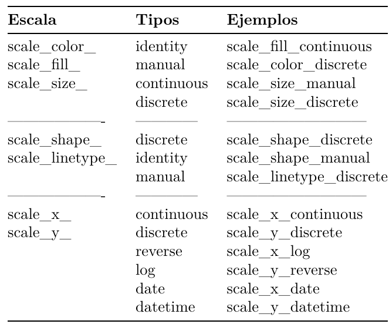

## Facetas (pequeños múltiplos)

- Para facilitar la comparación de gráficos (no solo objetos geométricos), se divide en subgráficos para distintos subconjuntos de los datos

```r
graf_estad <- ggplot(housing, aes(x = Date, y = Home.Value))
graf_estad +  geom_line(aes(color = State))                  # gráfico confuso
```

- `facet_wrap()` para facetas en función de variable discreta (usando “fórmula”)

```r
graf_estad +  geom_line() + facet_wrap(~State, ncol = 10)
```

- `facet_grid()` para facetas en dos dimensiones

```r
g3 <- ggplot(data = housing[housing$Year>2005,]) + geom_histogram(aes(x=Home.Value))
g3 +  facet_grid(region ~ Year)

g3 + facet_grid(region ~ .)     # También solo por filas
g3 + facet_grid(. ~ region)     # o columnas
```

## Contexto con `labs()`: título, ejes, leyendas

```r
ggplot(hp2001Q1, aes(y = Structure.Cost, x = Land.Value)) +
    geom_point(aes(color = region)) + geom_smooth(method = "lm", se = FALSE) +
    labs(title = "Relación entre el coste de la construcción y el valor del terreno",
         subtitle = "Datos del Primer Trimestre de 2001",
         caption = "Fuente: Elaboración propia")
```

- Es una buena idea que los nombres de ejes, leyendas, etc. sean descripciones claras de las variables (y sus unidades)

```r
ggplot(hp2001Q1, aes(y = Structure.Cost/1000, x = Land.Value/1000)) + scale_x_log10()+
    geom_point(aes(color = region)) + geom_smooth(method = "lm", se = FALSE) +
    labs(x = "Valor del terreno (miles de $), escala logarítmica",
         y = "Valor de la construcción (miles de $)",
         colour = "Región") +
    scale_y_continuous(breaks=seq(80,200,40),labels=as.character(seq(80,200,40)) )
```

- ¿Qué hace la escala logarítmica? ¿Y usar `x = log(Land.Value/1000)`?

## Otros elementos de contexto

- Ya vimos `geom_text()` para asociar una variable a un estética de etiqueta
- `annotate()` añade objetos geométricos no asociados a variables: “text”, “rect”, “segment”, “pointrange”

```r
ggplot(hp2001Q1, aes(y = Structure.Cost/1000, x = Land.Value/1000)) +
    geom_point(aes(color = region)) + geom_smooth(method = "lm", se = FALSE) +
    scale_x_log10()+
    annotate("text", x = 140, y = 180, label = "valor atípico") +
    annotate("text", x = 110, y = 150, label = "italic(R) ^ 2 == 0.026", parse = TRUE)
```

- Se pueden añadir líneas de referencias verticales, horizontals o diagonales

```r
  g2 +
    geom_vline(aes(xintercept = 1), linetype = 3, color = "black")
```

## Cambiar colores

- Se puede cambiar **manualmente** la combinación (paleta) de colores por defecto dando el nombre o el [código hexadecimal HTML](https://html-color-codes.info/codigos-de-colores-hexadecimales/) de color

```r
graf <- ggplot(hp2001Q1, aes(x = region, y = Home.Value, fill = region)) + geom_boxplot()

graf + scale_fill_manual(values = c("red", "green", "blue", "yellow", "gray"))
graf +
  scale_fill_manual(values = c("#004f71", "#465a01", "#981d97", "#00FFFF", "#848484"))
```

- Existen **paletas predefinidas**, con criterios de diseño y visualización de información, como [`RColorBrewer`](http://www.colorbrewer2.org) o [`viridis`](https://cran.r-project.org/web/packages/viridis/vignettes/intro-to-viridis.html) (replica `matplotlib` de Python)

```r
library("RColorBrewer")
display.brewer.all()

graf + scale_fill_brewer(palette = "Set3")
graf + scale_fill_brewer(palette = "Dark2")
```

## Temas

- Podemos definir el estilo general del gráfico (no solo la paleta de colores)
  - Etiquetas de los ejes
  - Fondo del gráfico
  - Fondo de las etiquetas en las facetas
  - Aparicencia de las leyendas

```r
graf + theme_gray()       # predeterminado
graf + theme_linedraw()
graf + theme_light()
graf + theme_minimal()
graf + theme_dark()
graf + theme_classic()
```

## Temas (cont.)

- Ciertos elementos específicos del tema pueden ser cambiados con `theme()`

```r
  graf + theme_minimal() + theme(text = element_text(color = "turquoise"))
```

- Y guardar los cambios en un objeto para crear un nuevo tema.

```r
tema_nuevo <- theme_minimal() + theme(text = element_text(color = "turquoise"))
graf + tema_nuevo
```

- `ggthemes` tiene temas creados y usados por otros usuarios o profesionales

```r
#install.packages("ggthemes")
library("ggthemes")
graf +  theme_economist() +  #  estilo del equipo de diseño gráfico de "The Economist"
  scale_fill_economist()
```

- Distintos colores de fondo, rediseño de ejes, cambio de posición de la leyenda

## Comentarios finales

- Guardar los gráficos: comando `ggsave`

```r
ggsave("my-plot.pdf")
```

- Ayuda en RStudio, *Help > Cheatsheets > Data Visualization with ggplot2*
- Fuentes de información con chuletas de R y RStudio [aquí](https://www.rstudio.com/resources/cheatsheets/)
  - existen versiones en castellano de algunas de ellas.

## Poniéndolo todo junto

- Estamos en condiciones de recrear gráficos profesionales como [este](http://www.economist.com/node/21541178) de `The Economist`